# Ford GoBike System Trip Data:

# Comparison of Factors Leading to Longer Rides in San Francisco

## By Omar Sayed

## Introduction

The Ford GoBike System dataset is a database of over 180,000 bike rides in the city of San Francisco. This data set includes information about individual rides made in a bike-sharing system covering the greater San Francisco Bay area during the month of February. This analysis aims to show the relationship between frequency of bike rides and time of day and day of week, as well as take a glance at some of the factors that lead to longer bike rides.

### Questions

Q1. When are most trips taken in terms of time of day and day of the week?

Q2. How long does the average trip take?

Q3. Do subscribers take longer trips on average than customers?

Q4. Do customers take longer bike rides on average than subscribers throughout the day/week?

*Q1. When are most trips taken in terms of time of day, day of the week?*

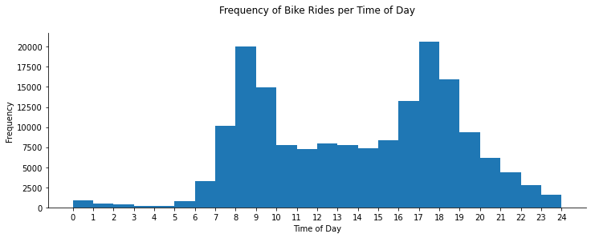

```python
#Plot frequency of bike rides per time of day
plt.figure(figsize = [12,4])
plt.hist(gobikes['start_hour'], bins = np.arange(0, 25, 1))
set_labels('Time of Day', 'Frequency','Frequency of Bike Rides per Time of Day')
remove_spines()
plt.xticks(np.arange(0, 25, 1))
plt.show();
```

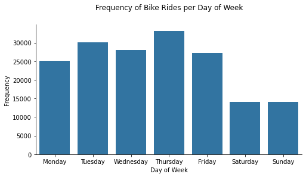

```python
#plotting most bike rides per starting day of week
plt.figure(figsize = [8,4])
sb.countplot(gobikes['start_day'], color = colors)
set_labels('Day of Week','Frequency','Frequency of Bike Rides per Day of Week')
remove_spines()
plt.show();
```

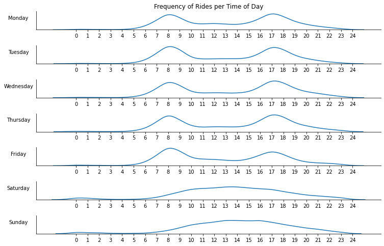

```python
#Frequency of bike rides per time of day
g = sb.FacetGrid(data = gobikes, row = 'start_day', aspect=10, height=1)
g.map(sb.kdeplot, 'start_hour')
g.set(yticks=[], xlabel = '')


for i, axes_row in enumerate(g.axes):
    for j, axes_col in enumerate(axes_row):
        col, row = axes_col.get_title().split('=')

        if i == 0:
            axes_col.set_title('Frequency of Rides per Time of Day')
            g.set(xticks = np.arange(0,25,1))
            g.set_xticklabels(labels = np.arange(0,25,1))
        else:
            axes_col.set_title('')

        if j == 0:
            ylabel = axes_col.get_ylabel()
            axes_col.set_ylabel(row.strip() + ylabel, rotation=0, labelpad = 35)

for ax in g.axes.flatten():
    ax.tick_params(labelbottom=True)
plt.show();
```

*Q2 How long does the average trip take?*

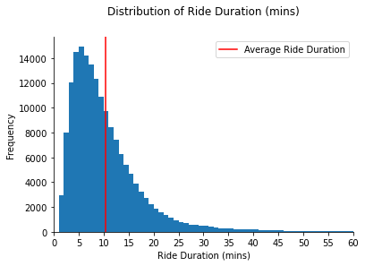

```
Average Trip Duration: 10 minutes
```

```python
#histogram of ride duration in minutes limited to 60 minutes
plt.hist(gobikes['duration_min'], bins = np.arange(0,gobikes['duration_min'].max()+1,1))
plt.axvline(gobikes['duration_min'].mean(), color='red', label='Average Ride Duration')
plt.xticks(np.arange(0,65,5))
plt.xlim(0,60)
set_labels('Ride Duration (mins)', 'Frequency', 'Distribution of Ride Duration (mins)')
remove_spines()
plt.legend()
plt.show()

print('Average Trip Duration: {:.0f} minutes'.format(gobikes['duration_min'].mean()))
```

A histogram of the ride duration in minutes shows a positively skewed distribution, with an average ride duration of a little over 10 minutes.

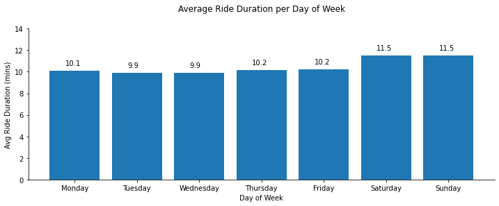

```python
#plotting bar chart of average ride duration per weekday
plt.figure(figsize=[12,4])
plt.bar(data = days_means  , x='start_day', height = 'duration_min')
plt.yticks(np.arange(0,15,2))
remove_spines()
set_labels('Day of Week', 'Avg Ride Duration (mins)','Average Ride Duration per Day of Week')

for i, v in enumerate(days_means['duration_min']):
    plt.text(i-0.15, v+0.5, '{:.1f}'.format(v))

plt.show();
```

A bar chart of the average ride duration in minutes shows a negatively skewed distribution with longer rides on average being taken on weekends than on weekdays

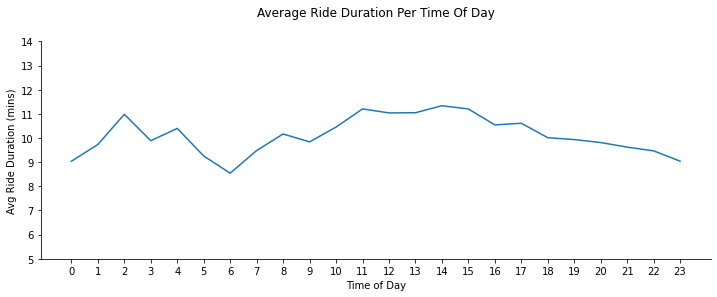

```python
#plotting average ride duration per time of day
plt.figure(figsize=[12,4])
hours_means['duration_min'].plot()
plt.xticks(np.arange(0,24,1))
plt.yticks(np.arange(5,15,1))
remove_spines()
set_labels('Time of Day','Avg Ride Duration (mins)','Average Ride Duration Per Time Of Day')
plt.show();
```

A simple line chart of the average ride durations per time of day shows that, overall, the longest rides on average occur between the hours of 11 AM - 3 PM, with the shortest rides on average occuring at around 6 AM.

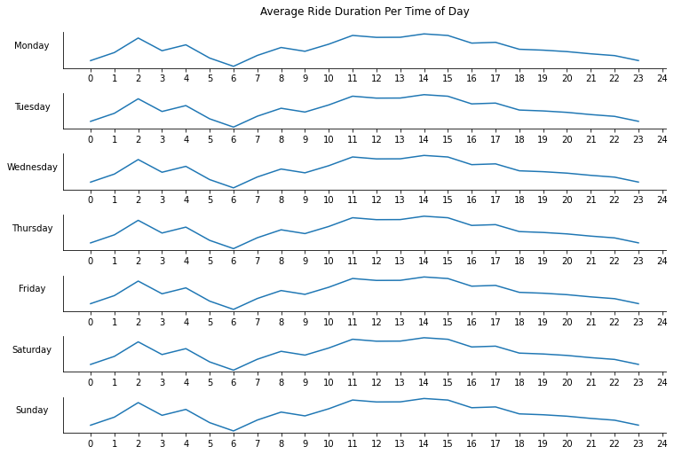

```python
g = sb.FacetGrid(data = gobikes, row = 'start_day', aspect=10, height=1)
g.map(hours_means['duration_min'].plot)

g.set(yticks=[], xlabel = '')


for i, axes_row in enumerate(g.axes):
    for j, axes_col in enumerate(axes_row):
        col, row = axes_col.get_title().split('=')

        if i == 0:
            axes_col.set_title('Average Ride Duration Per Time of Day', pad=20)
            g.set(xticks = np.arange(0,25,1))
            g.set_xticklabels(labels = np.arange(0,25,1))
        else:
            axes_col.set_title('')

        if j == 0:
            ylabel = axes_col.get_ylabel()
            axes_col.set_ylabel(row.strip() + ylabel, rotation=0, labelpad = 35)

for ax in g.axes.flatten():
    ax.tick_params(labelbottom=True)
plt.show();
```

*Q3 Do customers take longer bike rides than subscribers?*

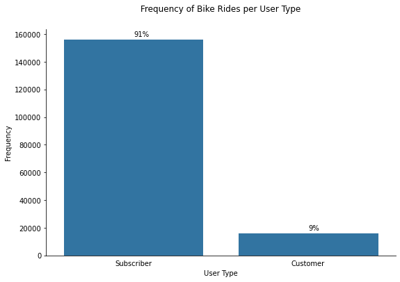

```python
#plotting number of subscribers vs number of customers

props = []
for i in gobikes['user_type'].value_counts(normalize=True).values:
    props.append('{:.0%}'.format(i))


plt.figure(figsize=[9,6])
ax = sb.countplot(data = gobikes, x='user_type', color = colors)
ax.tick_params(bottom=False)
for i, v in enumerate(props):
    ax.text(i,gobikes['user_type'].value_counts()[i]+2500, v)
set_labels('User Type', 'Frequency', 'Frequency of Bike Rides per User Type')
remove_spines()
plt.show();
```

A large majority of bike rides are by subscribers who make up 91% of GoBike users, whereas only 9% are regular customers.

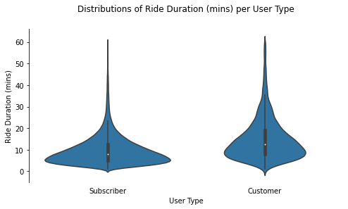

```
Average trip duration for Subscribers: 9.83 mins
Average trip duration for Customers: 14.98 mins
```

```python
plt.figure(figsize = [8,4])
sb.violinplot(x=gobikes['user_type'], y=gobikes['duration_min'], color = colors)
set_labels('User Type', 'Ride Duration (mins)', 'Distributions of Ride Duration (mins) per User Type')
remove_spines()
plt.gca().spines['bottom'].set_visible(False)
plt.gca().tick_params(bottom=False)
plt.show();

print('Average trip duration for Subscribers: {:.2f} mins'.format(subs_mean))
print('Average trip duration for Customers: {:.2f} mins'.format(cust_mean));
```

At a glance, we can see that customers on average take longer bike rides than subscribers, despite being much less frequent. This will be the basis of our hypothesis test to ensure that difference in average bike ride duration is significant.

the following hypthosis will be tested

- **$H_0$**: **$p_{0}$** $\leq$ **$p_{1}$**
- **$H_1$**: **$p_{0}$** $\gt$ **$p_{1}$**

given: **$p_{0}$** = average ride duration of customers **$p_{1}$** = average ride duration of subscribers

```python
#number of customers
n_cust =  gobikes.query('user_type == "Customer"').shape[0]

#number of subscribers
n_sub =  gobikes.query('user_type == "Subscriber"').shape[0]

#average trip duration of subscribers
subs_mean = gobikes.query('user_type == "Subscriber"')['duration_min'].mean()

#average trip duration of customers
cust_mean = gobikes.query('user_type == "Customer"')['duration_min'].mean()

#Compute z-score, p-value using statsmodels z-test
z_score, p_value = sm.stats.proportions_ztest([cust_mean, subs_mean], [n_cust, n_sub], alternative = 'larger')
print('Z-score: {:.3f}\n'.format(z_score), 'p-value: {:.3f}'.format(p_value))
```

```
Z-score: 8.834
 p-value: 0.000
```

With a z-score of 8.83 and a p-value of 0.00, above the critical value of 1.645 at an alpha of 0.05, we can reject the null hypothesis and we have sufficient evidence to support the alternative that customers do take longer bike rides on average than subscribers

*Q4: Do customers take longer bike rides on average than subscribers throughout the day/week?*

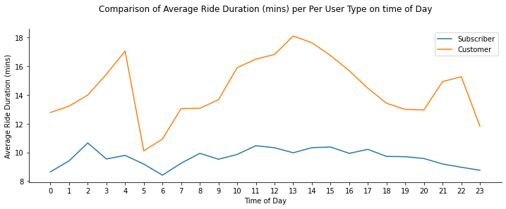

```python
#plotting line charts of average ride duration on each hour according to user type
plt.figure(figsize=[12,4])
subs_hourmeans['duration_min'].plot(label='Subscriber')
cust_hourmeans['duration_min'].plot(label='Customer')
remove_spines()
set_labels('Time of Day', 'Average Ride Duration (mins)', 'Comparison of Average Ride Duration (mins) per Per User Type on time of Day')
plt.xticks(np.arange(0,24,1))
plt.legend()
plt.show();
```

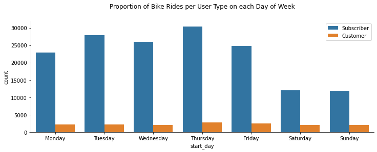

```python
#distribution of bike rides per user type on each day of week
plt.figure(figsize=[12,4])
sb.countplot(data = gobikes, x='start_day', hue='user_type')
remove_spines()
plt.title('Proportion of Bike Rides per User Type on each Day of Week', pad = 25)
plt.legend()
plt.show()
```

We can see that customers take a similar amount of bike rides throughout the week, while subscribers are less frequent on weekends than weekdays

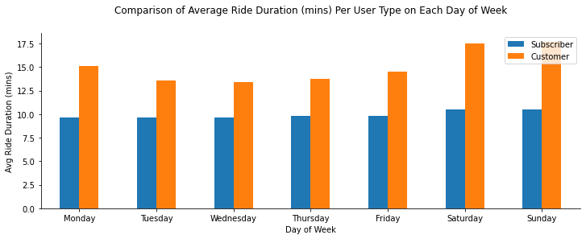

```python
#comparing average ride durations of users on each day
user_daymeans.plot(kind='bar', figsize=[12,4])
plt.legend(loc='upper right')
plt.xticks(rotation=0)
remove_spines()
set_labels('Day of Week', 'Avg Ride Duration (mins)', 'Comparison of Average Ride Duration (mins) Per User Type on Each Day of Week')
```

An interesting insight we can see from the two graphs above is that while customers take similarly frequent rides on weekdays, they take longer rides on average during weekends. On the other hand, subscribers take similarly long rides throughout the week regardless of weekday.  
Overall, customers take longer rides on average regardless of weekday.

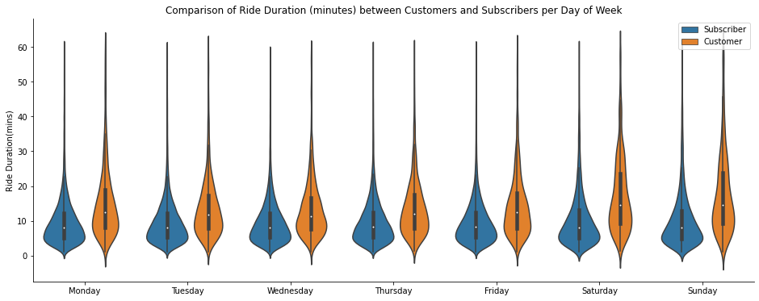

```python
plt.figure(figsize=[16,6])
sb.violinplot(data=gobikes, x='start_day', y='duration_min', hue='user_type')
plt.gca().spines['right'].set_visible(False)
plt.gca().spines['top'].set_visible(False)
plt.xlabel('')
plt.ylabel('Ride Duration(mins)')
plt.title('Comparison of Ride Duration (minutes) between Customers and Subscribers per Day of Week')
plt.legend()
plt.show();
```

The above violin plot comparison of ride durations between customers and subscribers throughout the days of the week further affirms that customers take longer bike rides on average regardless of the day of week, which further supports our hypothesis that customers take longer bike rides than subscribers.

# Conclusion

## Limitations

There are some limiations in this dataset, including but not limited to:

- This dataset only includes bike rides during one month, comparing bike rides throughout the year could lead to interesting results.
- The dataset includes bike rides only in San Franscisco. San Franscisco is a generally variable landscape in terms of topography and has some high slopes to navigate. It would be interesting to compare bike riding patterns in different cities.